# UCLA Library Data Science Center

What we built, 2017–2026

2026-09-28

The Data Science Center grew out of UCLA’s Social Science Data Archive, an archive that dates to 1961 and was a founding member of ICPSR. Since 2017 it has become something broader: general-purpose research data infrastructure, instruction, and consulting used across the university. This is a record of what that build looks like, in numbers and in the work it supported.

**In short:** UCLA Dataverse has grown from 9 datasets in 2020 to roughly 1,390 released today. DSC’s Redivis platform, built around a 10-terabyte national voter file that could not be analyzed as delivered, has since processed 4.8 petabytes of restricted research data. Since 2017 DSC has run 819 workshop sessions (through May 2026) and counted 27,986 registered workshop seats (through September 2026). GIS support ended in 2024 when the GIS librarian position was eliminated; DSC still receives GIS requests.

## A 65-year lineage

**1961** Political Behavior Archive founded by Dwaine Marvick

**1962** Founding member, Inter-university Consortium for Political and Social Research (ICPSR)

**1977** Becomes the Social Science Data Archive under the Institute for Social Science Research

**2014–15** MOU transfers the Archive to UCLA Library (Dean Duranti / UL Steel)

**2018** Data Science Center founded as the Archive’s institutional home

**2017–2026** Build-out: AI/ML, GIS, 3D and spatial curation, a research data repository, an open source program, a student workforce

One person bridges nearly the whole modern era: **Jamie Jamison**, who transferred with the Archive in 2014, is still on the DSC team today.

## 2017 to 2026: what was built, and when capacity changed

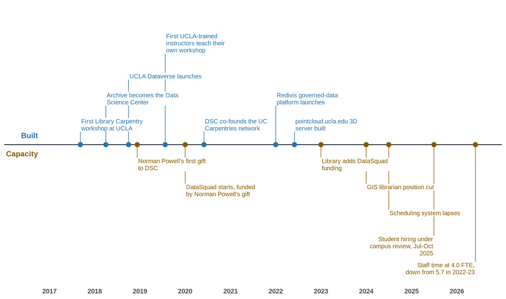

Above the line: services and programs as they entered DSC’s portfolio. Below: funding and capacity changes. Positions within a year are approximate where only the year is known. The full dated list, with sources, follows the chart.

**All dated events, with sources**

- **Apr 17, 2017** (built): Tim Dennis starts as director. *Source: Tim’s 2017-2019 Office Timeline chart.*
- **Sep 7, 2017** (built): First Library Carpentry workshop at UCLA. *Source: Tim’s 2017-2019 Office Timeline chart.*
- **Oct 16, 2017** (built): First Software Carpentry workshop at UCLA. *Source: Tim’s 2017-2019 Office Timeline chart.*
- **Oct 17, 2017** (built): Social science workshop sequence (data literacy, SQL, R, Python), Oct-Nov 2017. *Source: Tim’s 2017-2019 Office Timeline chart.*
- **Mar 5, 2018** (built): SSDA moves into Young Research Library. *Source: Tim’s 2017-2019 Office Timeline chart.*
- **Apr 2018** (built): Archive becomes the Data Science Center. *Source: Tim’s chart (Apr 2018); #ucladatascience in use by Oct 16, 2018 (@ucla_ssda post); Library location page first archived Jun 28, 2019 (Wayback Machine).*
- **May 2018** (built): Carpentries membership. *Source: Tim’s 2017-2019 Office Timeline chart.*
- **Oct 2018** (built): UCLA Dataverse launches. *Source: Tim’s chart; first dataset published Oct 31 2018.*
- **Nov 6, 2018** (built): Research Data Services Task Force report. *Source: Tim’s 2017-2019 Office Timeline chart.*
- **Dec 10, 2018** (capacity): Norman Powell’s first gift to DSC. *Source: Tim’s 2017-2019 Office Timeline chart.*
- **Jan 9, 2019** (built): First UCLA cohort of eight Carpentries instructors trained and certified, Jan-Aug 2019. *Source: Tim’s 2017-2019 Office Timeline chart.*
- **Jul 24, 2019** (built): First UCLA-trained instructors teach their own workshop. *Source: Tim’s 2017-2019 Office Timeline chart.*
- **Sep 25, 2019** (built): AfAm 188 / Million Dollar Hoods technical workshop, Sep-Dec 2019. *Source: Tim’s 2017-2019 Office Timeline chart.*
- **Dec 15, 2019** (capacity): Norman Powell’s second gift to DSC. *Source: Tim’s 2017-2019 Office Timeline chart.*
- **2020** (capacity): DataSquad starts, funded by Norman Powell’s gift. *Source: _partials/datasquad.qmd.*
- **2020** (built): DSC co-founds the UC Carpentries network. *Source: claim-register.md #15.*
- **2022** (built): Redivis governed-data platform launches. *Source: _partials/redivis-l2.qmd.*
- **2022** (built): pointcloud.ucla.edu 3D server built. *Source: research.qmd; claim-register.md #20.*
- **2023** (capacity): Library adds DataSquad funding. *Source: _partials/datasquad.qmd.*
- **2024** (capacity): GIS librarian position cut. *Source: _partials/gis-support.qmd.*
- **Jul 2024** (capacity): Scheduling system lapses. *Source: service_capacity_by_year.csv; research.qmd.*
- **Jul 2025** (capacity): Student hiring under campus review, Jul-Oct 2025. *Source: service_capacity_by_year.csv.*
- **2026** (capacity): Staff time at 4.0 FTE, down from 5.7 in 2022-23. *Source: service_capacity_by_year.csv; claim-register.md #17.*

## DSC today, by the numbers

~1,390 Released datasets in UCLA Dataverse, Feb 2026 About 376 deposited directly at UCLA plus about 1,014 legacy SSDA datasets curated by Library staff; up from 9 in Jan 2020 (1,603 counting drafts and restricted deposits)

143,000+ File-level download events since 2020, as of Feb 2026 229 in Jan 2020 → 143,000+ in Feb 2026; see the infrastructure page for the current count

27,986 Registered workshop seats since 2017 May 2017 to Sept 2026; registrations, not people; 819 sessions through May 2026

about 1,850 Recorded consultations since 2017 A floor: recording lapsed from mid-2024

**Where these numbers come from**

**Data currency:** Registered workshop seats run through September 2026 (2026 is partial); the session count runs through May 2026. Consultations run through September 2026 and are a floor from mid-2024 on, when recording lapsed. Dataverse infrastructure figures are current through February 2026. Full methodology: [dsc-stats-reports/about](https://ucla-data-science-center.github.io/dsc-stats-reports/about.html).

Together these describe a shift: DSC has grown from a specialized archive service into general-purpose research infrastructure used across the university, the kind of reach the 2014 transfer was meant to enable.

## What we cover

DSC’s work spans the research data lifecycle and the methods that have grown up around it: data management and curation, data cleaning and analysis, geospatial methods and GIS, 3D and drone-based scanning, machine learning and AI, research software engineering, reproducible workflows, and open source and open science practice. Consultations and workshops touch nearly every division: the largest single workshop constituency is Geography, and social science departments together account for about 1 in 8 attendees, but Life Sciences, Physical Sciences, Public Health, Medicine, Humanities, and the professional schools are all steady users.

Social science departments have stayed a core constituency throughout: roughly 200 workshop participants since 2020 from Geography, Psychology, Political Science, Sociology, Economics, Anthropology, Urban Planning, Public Policy, and Gender Studies, plus people who registered simply as “Social Science.” That share has held steady even as DSC’s overall reach grew, evidence the 2014 move broadened the Archive’s audience without leaving its original constituency behind.

## Redivis and the L2 voter file

DSC turned a 10-terabyte national voter file, delivered as thousands of inconsistent state files, into a resource researchers across campus now use directly.

DSC piloted **Redivis**, a secure platform for restricted research data, initially supported by University Librarian discretionary funds. It’s since grown into a sustained subscription, about ~$47K/year as of 2026, paid through Library central finance alongside ICPSR and Roper. The platform holds about ~20TB of P3/P4-compliant data across 50 registered users and over 150+ workflows, and has processed **4.8 petabytes** cumulatively since it launched in 2022.

The flagship dataset is the **L2 historic voter file**, over 10TB of national voter history purchased by DSC and a Library subject selector. It arrived as thousands of fragmented, state-level files, too large to store locally and too inconsistent to analyze as-is. DSC consolidated it into a single, version-controlled, analysis-ready dataset, cited by Redivis’s own CEO as a flagship use case at FORCE11 2024.

Researchers use it directly across departments: election administration (Joshua Ferrer, Political Science), gentrification patterns (Alexandria Davis, Political Science), population behavior and public policy (Economics), and a project merging the voter file with UCLA medical records to study health and voting (Straus, Thompson, Vavreck, Naeim, UCLA Health). As the graduate student who curated the dataset put it:

> *“Professors and students in a social sciences department are able to instantly work with a large, rich dataset in a secure environment.”* — Graham Straus, UCLA Political Science PhD student, FORCE11 2024

## GIS and geospatial support

UCLA cut its GIS librarian position in 2024. GIS requests continued.

Geography has consistently been DSC’s single largest workshop constituency: 64 of the 1,575 UCLA-affiliated workshop attendance records from 2020 to April 2024, more than any other department.

Before the position was eliminated in 2024, DSC’s GIS librarian handled 72 to 82 booked consultations a year (2021 to 2023) across Urban Planning, Public Affairs, Environment and Sustainability, and Digital Humanities. They also co-taught a graduate Public Health course, ran systemwide UC GIS workshops that reached 617 participants in 2023 alone, and managed key research datasets, including the LARIAC aerial imagery acquired through the Archive’s gift fund. That demand hasn’t gone away. DSC still fields GIS requests, just without the specialist capacity to meet them.

Nationally, 81 of 187 Carnegie R1 institutions (43%) maintain a dedicated GIS librarian, rising to 81% among the top 25 R&D-spending universities. UCLA has the highest research expenditure of any UC campus, yet is one of only two UC R1 campuses without one. The other, Santa Cruz, spends a fraction of what UCLA does on research. (UCSF also lacks one, but it’s a health-sciences-only campus with no undergraduates, not a fair comparison.) Lower-spending UC peers like Berkeley and San Diego both maintain dedicated GIS staff.

The campus mapping platform is a separate gap, a matter of ownership rather than consultation demand. UCLA’s ArcGIS Online platform, used across Geography, Luskin, Fielding, Digital Humanities, Political Science, and Social Data Science, has over 7,100 accounts and more than 3,000 active users in the past year, per an OARC governance report from December 2025. Without a designated administrator, it’s now running at over 200% of its licensed storage.

## Consulting spotlights

### Carceral Ecologies

Partner: UCLA Institute for Society and Genetics (Nicholas Shapiro)

DSC staff and DataSquad students cleaned and integrated the lab’s helicopter flight data, provided GIS support, refactored the R code, and moved the analysis onto DSC computing as the lab acquired larger datasets. A student researcher on the project first learned R and GIS from DSC staff in a 2019 African American Studies course taught with DSC, then worked with DSC and DataSquad more than 30 times in 2022.

> *“This work wouldn’t have happened without your team!”* — Nicholas Shapiro, director of Carceral Ecologies, November 2024 (quoted with permission)

**Outcome:** one measured piece of the work cut the time to load the data from about 318 minutes to about 2, about 159 times as fast. The research and its findings belong to the lab; Shapiro received a 2024 UCLA Public Impact Research Award for it.

### BioCritical Studies Lab

Partner: UCLA Institute for Society and Genetics (Terence Keel; Grace Sosa)

DataSquad students have worked on the lab’s national deaths-in-custody dataset since 2021: merging and reconciling sources, identifying missed deaths, statistical comparisons, dashboards and maps, and integration code and a codebook the lab uses to update the dataset itself.

> *“The work the DataSquad has done has helped us address this need and has allowed us to maintain this dataset over time and through revisions.”* — Grace Sosa, assistant director, BioCritical Studies Lab, August 2024 (quoted with permission)

**Outcome:** DSC contributed data integration, analysis, and visualization support to research later recognized through UCLA’s 2024 Public Impact Research Awards.

### Refugee Material Culture Initiative

Partner: Professor Kelly Nguyen (Classics) and the Vietnamese Heritage Museum

Doug Daniels, DSC’s emerging technologies librarian, 3D scanned the “Boat of Hope,” a river sampan that carried nine refugees out of Vietnam in 1984, and prepared the models for the museum’s digital exhibit. Student employee Bianca Badajos helped set up the Potree viewer on pointcloud.ucla.edu, where the model is hosted.

**Outcome:** a public 3D model anyone can explore in a web browser ([Boat of Hope](https://www.pointcloud.ucla.edu/VHM/narrative_all.html)), which depends on DSC’s continued hosting.

Full accounts and sources: [Research enabled](https://ucla-data-science-center.github.io/dsc-stats-reports/research.html#three-collaborations).

## DataSquad

DataSquad logged 111 reportable project tasks in 2025.

DataSquad is DSC’s peer-consulting model: undergraduate and graduate student consultants providing sustained project support alongside DSC staff’s direct consultations. It logged **111 reportable project tasks in 2025**, much of it sustained, hands-on project support rather than one-off questions. Task tracking in Trello began in 2023, so the rise from 6 tasks that year partly reflects record-keeping, not only more work.

The program started in 2020 on a gift from **Norman Powell**, which funded student salaries and laptops for the first cohort. The Library added funding in 2023 to expand the team and add in-person hours. In 2024, DataSquad absorbed the LuxLab student program after its funding source, CLICC funds, became restricted, merging two student-support lines into one.

## Emerging technology and 3D curation

Doug Daniels, DSC’s emerging technologies librarian, was named UCLA’s 2026 LAUC-LA Librarian of the Year.

The award, one of two given university-wide by LAUC-LA in a 15-nomination, peer-selected cycle, recognized partnerships across archaeology, digital humanities, medical sciences, materials science, and Egyptology, including the Refugee Material Culture Initiative above and a drone survey of Iceland’s Mosfell Valley with a doctoral student from the Cotsen Institute of Archaeology. A separate Lux Lab collaboration, a surgical probe holder built with an undergraduate student, is now in clinical use at Ronald Reagan UCLA Medical Center.

**Potree**, the spatial-visualization platform DSC runs alongside Dataverse, is what turns this work into something researchers can use rather than just store: 3D scans and point-cloud data become interactive models, explorable in a browser instead of sitting as a static file in an archive.

> *“Daniels’ work has strengthened partnerships across campus and throughout the greater Los Angeles community while helping students succeed with their individual research projects.”* — Patrick Lavey, LAUC-LA Award Committee Chair, [UCLA Newsroom](https://newsroom.ucla.edu/stories/doug-daniels-matthew-vest–ucla-librarians-of-the-year-2026)

## Instruction

2020

208

2021

218

2022

414

2023

464

2024*

372

*2024 partial (data through April); a fuller reconciliation across DSC’s several registration systems is in progress.

Workshops cover geospatial methods, programming, reproducibility, data management, and open science, and reach far beyond any single division. DSC also coordinates UCLA’s participation in systemwide efforts including UC Love Data Week and UC GIS Week.

## Open science and software curation

$2.09M in competitive federal and foundation funding supports this work.

DSC’s open source program office (OSPO) work, licensing review, repository best practices, and release guidance, is funded through a **$1.85M Sloan Foundation grant**. It exists because the need is real: a 2025 scan of roughly ~81,000 UC-affiliated code repositories found 77.5% carried no license at all, meaning most UC research code cannot legally be reused or built on.

Alongside it, a **$237,839 IMLS grant** (Laura Bush 21st Century Librarian Program, RE-252335-OLS-22) funded a 14-lesson open science curriculum built by and for librarians, developed by two cohorts across 2023-2024. Tim Dennis served as Program Director, Todd Grappone as Co-PI, and Zhiyuan Yao, DSC’s GIS librarian at the time, as Program Coordinator. All lessons are built on The Carpentries Workbench and released under CC-BY 4.0; one, DMP 101, has already been formally adopted into the Library Carpentry curriculum, with the rest in active community piloting.

That curriculum work sits inside a larger, ongoing commitment: Dennis co-chairs the **Library Carpentry Governance Group**, which sets lesson-adoption and curriculum-quality standards for the global Library Carpentry program, not just UCLA’s. DSC staff maintain or co-maintain lessons taught worldwide, from core Carpentries material (Unix Shell, Tidy Data, R, Python, Computational Thinking) to newer additions in qualitative data methods, data management, Wikidata, data archiving, and AI, including a published lesson on using AI coding agents in research while preserving validation and reproducibility (agentic-research-workflows). Dennis is also a [Center for Open Science Ambassador](https://www.cos.io/communities/ambassadors) (2016-present) and was teaching faculty for the Berkeley Initiative for Transparency in the Social Sciences’ [Research Transparency and Reproducibility Training](https://www.bitss.org/education/rt2/).

## Infrastructure

Dataverse has grown from 9 datasets in 2020 to roughly ~1,390 released by February 2026.

Dataverse, UCLA’s institutional repository, which DSC operates, has grown from 9 datasets and 229 downloads in January 2020 to roughly **~1,390 released datasets and over 143,000+ downloads** as of February 2026 (1,603 counting drafts and restricted deposits). This is the same hosting commitment the Library made in the 2014 transfer (“necessary technological infrastructure for continued hosting of software, data, and data analysis tools”), grown considerably since.

Dataverse and Redivis are funded through the original SSDA gift fund, University Librarian discretionary funds, and the Library’s central budget. The Archive’s core subscriptions (ICPSR, ~$47K/year, and the Roper Center, ~$8K/year) moved years ago onto the Library’s general membership fund, the same treatment other research libraries give large database subscriptions. That freed the Archive’s original gift fund to cover the AWS infrastructure costs for Dataverse and Potree instead.

The full public dashboard, with current figures and methodology, is at [ucla-data-science-center.github.io/dsc-stats-reports](https://ucla-data-science-center.github.io/dsc-stats-reports/).

Tim Dennis  
Data Science Center, UCLA Library